# Semibalanus shading experiment

Amelia Hesketh

06/10/2021

# Objectives

This experiment is designed to document how communities differ (in terms of Shannon diversity, species richness, and total abundance of organisms) between Semibalanus beds that are shaded vs. unshaded during the summer season. Shades reduce temperature (and desiccation stress). I also scraped a subset of plots to see how early succession is affected by the presence or absence of shades.

I want to examine: 1) How communities differ in mulitdimensional space between treatments - what is their dispersion, and how far apart are they? 2) How Shannon diversity differs 3) How richness differs 4) How total abundance differs

# Temperature data

```r
library(tidyverse)
library(lubridate)
library(car)
library(vegan)

temp.files <- list.files("../raw_data/ibutton_temp/")

temp.df.all.aug <- data.frame(matrix(ncol = 4))
colnames(temp.df.all.aug) <- c("Date/Time", "Unit", "Value", "file_name")

for (file in 1: length(temp.files)){
  file.name = paste("../raw_data/ibutton_temp/", temp.files[file], sep = "")
  temp.df <- read_csv(file.name, skip = 14) %>% mutate(file_name = temp.files[file])
  if (str_detect(file.name, "07")==TRUE){
    if (file == 1){
    temp.df.all.july <- temp.df
  }
  if (file > 1){
    temp.df.all.july <- rbind(temp.df.all.july, temp.df)
  }
  }
  else {
    temp.df.all.aug <- rbind(temp.df.all.aug, temp.df)
  }
}

temp.df.clean.july <- temp.df.all.july %>% mutate(Value = str_remove_all(Value, "C,")) %>% separate(file_name, sep = "_", into = c("block","treatment","extra")) %>% select(-extra) %>% rename(date = 1, time = 2, temperature_C = 3) %>%
mutate(time = toupper(str_remove_all(time, fixed(".")))) %>% mutate(time = parse_time(time, "%I:%M:%S %p")) %>% unite(date_time, c(date, time), sep = " ") %>% mutate(date_time = as_datetime(date_time), temperature_C = as.numeric(temperature_C))

temp.df.clean.aug <- temp.df.all.aug %>% na.omit() %>% select(-Unit) %>% separate(file_name, sep = "_", into = c("block","treatment","extra")) %>% select(-extra) %>% rename(date_time = 1, temperature_C = 2) %>% mutate(date_time = parse_date_time(date_time, "%d/%m/%y %I:%M:%S %p"))

temp.clean <- temp.df.clean.aug %>%  full_join(temp.df.clean.july) %>% mutate(treatment = case_when(treatment == 1 ~ "UI", treatment == 2 ~ "SI", treatment == 3 ~ "UR", treatment == 4 ~ "SR")) %>% filter(date_time < "2021-08-21 6:00:00" & date_time > "2021-04-17 15:00:00") %>% unique()

#write_csv(temp.clean, "../clean_data/SBHW_temp_clean.csv")

# isolate low tide data only

temp.rounded <- temp.clean %>% mutate(hour = hour(date_time)) %>% separate(date_time, into = c("date","time"), sep = " ") %>% unite(date_time, c(date, hour), sep = " ") %>% mutate(date_time = ymd_h(date_time)) %>% select(-time)

tides_cc <- read_delim("../raw_data/tides/tides_all_summer_CC.csv", col_names = c("date","junk","time","tz","tide_height_ft"), delim = " ") %>% mutate(hour = hour(time)) %>% select(-junk, -tz, -time) %>% unite(date_time, c(date, hour), sep = " ") %>% mutate(date_time = ymd_h(date_time), tide_height_m = tide_height_ft * 0.3048) %>% select(-tide_height_ft)

temp.lowtide <- temp.rounded %>% left_join(tides_cc) %>% filter(tide_height_m <= 1.4)
```

```r
temp.sep <- temp.lowtide %>% separate(date_time, into = c("date","time"), sep = " ", remove = F)

temp.hourly <- temp.lowtide %>% group_by(date_time, treatment) %>% summarize(mean_temp = mean(temperature_C)) %>% separate(date_time, into = c("date","time"), sep = " ", remove = F) %>% mutate(date_time = ymd_hms(date_time))
temp.summary <- temp.sep %>% group_by(date, treatment) %>% summarize(mean_temp = mean(temperature_C), max_temp = max(temperature_C)) %>% mutate(date = date(date))
```

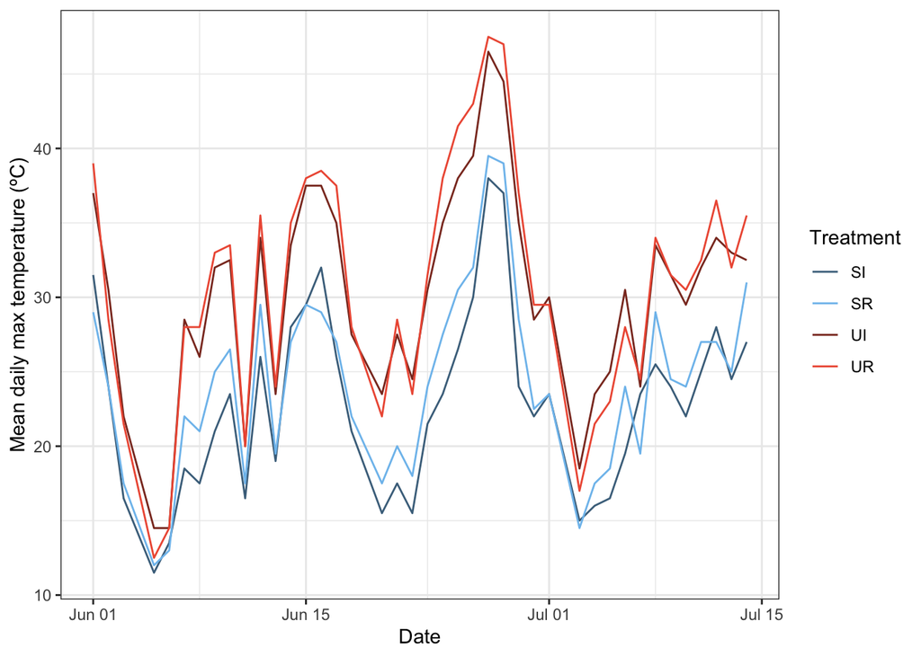

```r
ggplot(data = temp.summary %>% filter(date >= "2021-06-01" & date < "2021-07-15") , aes(x = date, y = max_temp, col = treatment)) + geom_line() + scale_color_manual(values = c("skyblue4","skyblue2", "tomato4", "tomato2")) + labs(x = "Date", y = "Mean daily max temperature (ºC)", color = "Treatment") + theme(axis.title = element_text(size = 14), axis.text = element_text(size = 12), legend.text = element_text(size = 12), legend.title = element_text(size = 14)) + theme_bw()
```

```r
View(temp.clean)
```

The temperature is highest in the unshaded treatments (as expected) by (at times) a substantial margin. What does this break down to in a boxplot sense?

```r
temp.summary2 <- temp.sep %>% group_by(treatment, date) %>% summarize(mdmax_temp = max(temperature_C)) %>% mutate(trt_long = case_when(treatment == "SI" ~ "shaded intact", treatment == "UI" ~ "unshaded intact", treatment == "SR" ~ "shaded removal", treatment == "UR" ~ "unshaded removal"))
```

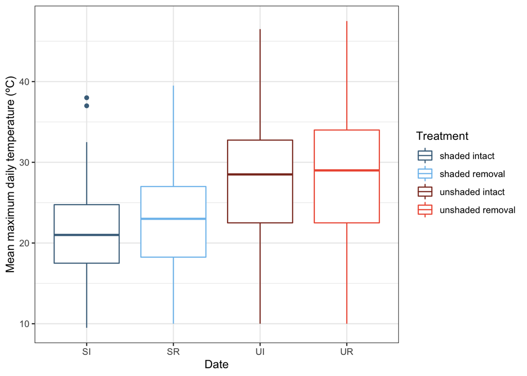

```r
ggplot(data = temp.summary2 %>% filter(mdmax_temp < 50), aes(x = treatment, y = mdmax_temp, col = trt_long)) + geom_boxplot() + scale_color_manual(values = c("skyblue4","skyblue2", "tomato4", "tomato2")) + labs(x = "Date", y = "Mean maximum daily temperature (ºC)", color = "Treatment") + theme_bw()
```

There’s something odd going on here with one of the SI plots. Need to look into it a bit more. Solved! Excluded one plot that was problematic.

```r
require(car)
require(lme4)
temp.model <- lmer(temperature_C ~ treatment*date_time + (1|block), data = temp.lowtide)
summary(temp.model)
```

```
## Linear mixed model fit by REML ['lmerMod']
## Formula: temperature_C ~ treatment * date_time + (1 | block)
##    Data: temp.lowtide
##
## REML criterion at convergence: 63922.7
##
## Scaled residuals:
##     Min      1Q  Median      3Q     Max
## -1.9908 -0.7888 -0.1205  0.6542  4.0603
##
## Random effects:
##  Groups   Name        Variance Std.Dev.
##  block    (Intercept)  0.2761  0.5255
##  Residual             43.5216  6.5971
## Number of obs: 9648, groups:  block, 5
##
## Fixed effects:
##                         Estimate Std. Error t value
## (Intercept)           -5.654e+01  7.653e+01  -0.739
## treatmentSR            5.214e+01  1.055e+02   0.494
## treatmentUI            2.567e+02  1.072e+02   2.395
## treatmentUR            3.409e+02  1.024e+02   3.329
## date_time              4.499e-08  4.711e-08   0.955
## treatmentSR:date_time -3.177e-08  6.492e-08  -0.489
## treatmentUI:date_time -1.558e-07  6.602e-08  -2.360
## treatmentUR:date_time -2.076e-07  6.306e-08  -3.292
##
## Correlation of Fixed Effects:
##             (Intr) trtmSR trtmUI trtmUR dat_tm trSR:_ trUI:_
## treatmentSR -0.712
## treatmentUI -0.707  0.503
## treatmentUR -0.734  0.516  0.529
## date_time   -1.000  0.712  0.707  0.734
## trtmntSR:d_  0.712 -1.000 -0.503 -0.516 -0.712
## trtmntUI:d_  0.706 -0.503 -1.000 -0.529 -0.706  0.503
## trtmntUR:d_  0.734 -0.516 -0.529 -1.000 -0.734  0.516  0.529
## fit warnings:
## Some predictor variables are on very different scales: consider rescaling
```

```r
Anova(temp.model)
```

```
## Analysis of Deviance Table (Type II Wald chisquare tests)
##
## Response: temperature_C
##                        Chisq Df Pr(>Chisq)
## treatment           631.1540  3  < 2.2e-16 ***
## date_time             6.4298  1   0.011222 *
## treatment:date_time  14.3627  3   0.002451 **
## ---
## Signif. codes:  0 '***' 0.001 '**' 0.01 '*' 0.05 '.' 0.1 ' ' 1
```

```r
max.temp.model <- lm(mdmax_temp ~ treatment, data = temp.summary2)

TukeyHSD(aov(mdmax_temp ~ treatment, data = temp.summary2))
```

```
##   Tukey multiple comparisons of means
##     95% family-wise confidence level
##
## Fit: aov(formula = mdmax_temp ~ treatment, data = temp.summary2)
##
## $treatment
##            diff        lwr      upr     p adj
## SR-SI 1.5252101 -0.8023388 3.852759 0.3303610
## UI-SI 6.0672269  3.7396780 8.394776 0.0000000
## UR-SI 6.5840336  4.2564847 8.911583 0.0000000
## UI-SR 4.5420168  2.2144679 6.869566 0.0000041
## UR-SR 5.0588235  2.7312746 7.386372 0.0000002
## UR-UI 0.5168067 -1.8107422 2.844356 0.9402615
```

```r
summary(max.temp.model)
```

```
##
## Call:
## lm(formula = mdmax_temp ~ treatment, data = temp.summary2)
##
## Residuals:
##      Min       1Q   Median       3Q      Max
## -17.8361  -4.7521   0.2479   4.7227  19.6639
##
## Coefficients:
##             Estimate Std. Error t value Pr(>|t|)
## (Intercept)  21.2521     0.6384  33.292  < 2e-16 ***
## treatmentSR   1.5252     0.9028   1.689   0.0918 .
## treatmentUI   6.0672     0.9028   6.721 5.23e-11 ***
## treatmentUR   6.5840     0.9028   7.293 1.29e-12 ***
## ---
## Signif. codes:  0 '***' 0.001 '**' 0.01 '*' 0.05 '.' 0.1 ' ' 1
##
## Residual standard error: 6.964 on 472 degrees of freedom
## Multiple R-squared:  0.1436, Adjusted R-squared:  0.1381
## F-statistic: 26.38 on 3 and 472 DF,  p-value: 8.684e-16
```

```r
Anova(max.temp.model)
```

```
## Anova Table (Type II tests)
##
## Response: mdmax_temp
##           Sum Sq  Df F value    Pr(>F)
## treatment   3837   3  26.375 8.684e-16 ***
## Residuals  22889 472
## ---
## Signif. codes:  0 '***' 0.001 '**' 0.01 '*' 0.05 '.' 0.1 ' ' 1
```

# Mortality in shaded vs. unshaded

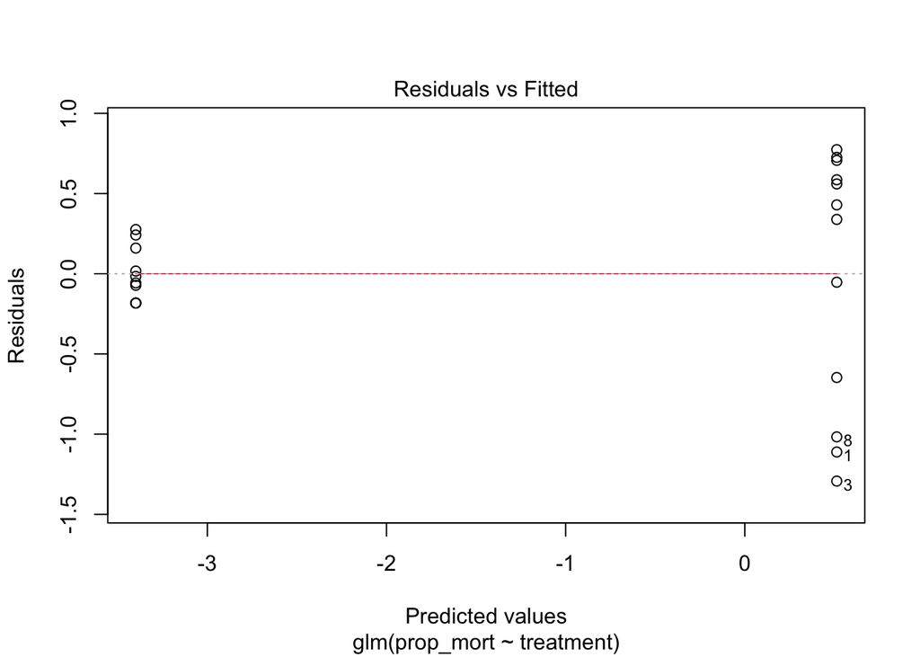

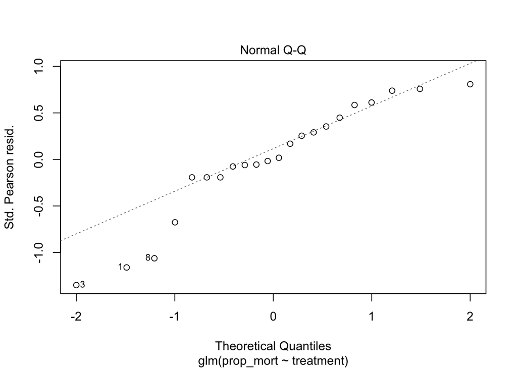

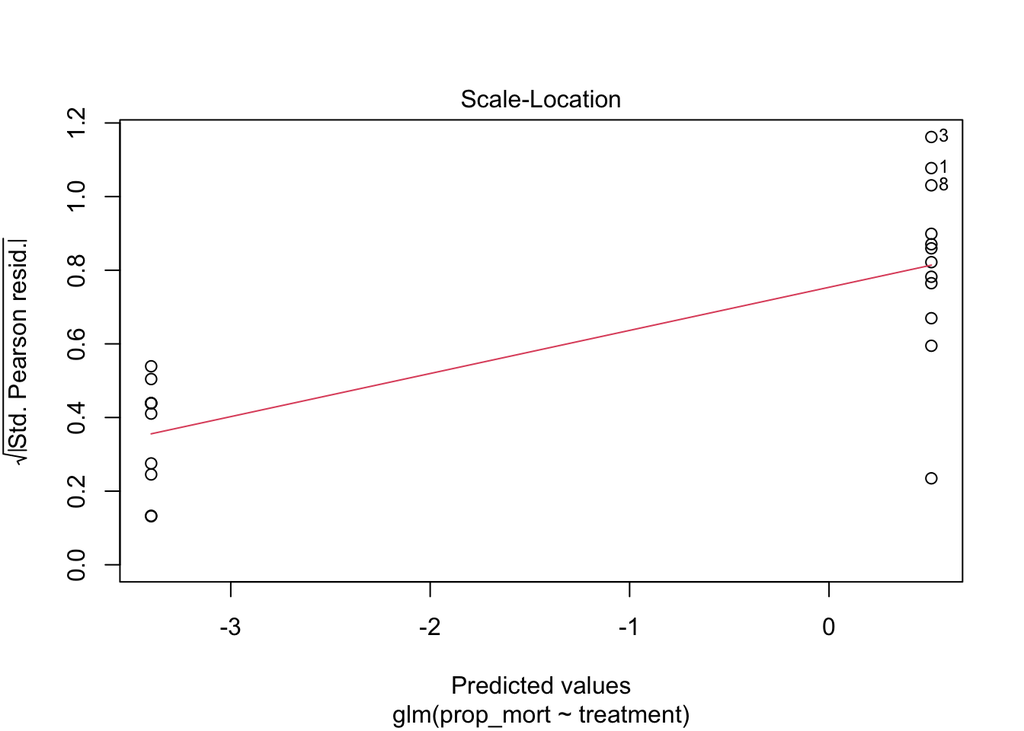

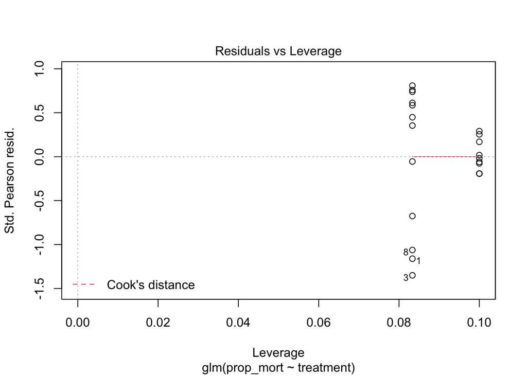

```r
barnacle.mort <- read_csv("../raw_data/shade/SBHW_SHADE_semibalanusmort.csv") %>% mutate(prop_mort = (number_dead)/(number_live+number_dead)) %>% filter(prop_mort != "NaN")

plot.info <- read_csv("../raw_data/shade/SBHW_SHADE_plot_info.csv")

mort.complete <- barnacle.mort %>% left_join(plot.info) %>% filter((plot_number %in% c(15,35,36,40)) == F) %>% select(prop_mort, treatment_original_numeric, plot_number, block) %>% rename(treatment = treatment_original_numeric) %>% mutate(treatment = case_when(treatment == 1 ~ "UI", treatment == 2 ~ "SI"))

mort.beds <- mort.complete %>% filter(treatment %in% c("SI","UI"))

shade.mort.model <- glm(prop_mort ~ treatment, family = "binomial", data = mort.beds)
plot(shade.mort.model)
```

```r
shade.mort.model.weights <- glm(prop_mort ~ treatment, family = "binomial", weights = treatment, data = mort.beds %>% mutate(treatment = case_when(treatment == "UI" ~ 1, treatment == "SI" ~ 2)))
AIC(shade.mort.model, shade.mort.model.weights)

# no weights

summary(shade.mort.model)
Anova(shade.mort.model)
summary(shade.mort.model)
```

[output not shown]

```
##
## Call:
## glm(formula = prop_mort ~ treatment, family = "binomial", data = mort.beds)
##
## Deviance Residuals:
##      Min        1Q    Median        3Q       Max
## -1.40162  -0.25634  -0.00007   0.43061   0.96865
##
## Coefficients:
##             Estimate Std. Error z value Pr(>|z|)
## (Intercept)   -3.399      1.788  -1.901   0.0573 .
## treatmentUI    3.912      1.885   2.076   0.0379 *
## ---
## Signif. codes:  0 '***' 0.001 '**' 0.01 '*' 0.05 '.' 0.1 ' ' 1
##
## (Dispersion parameter for binomial family taken to be 1)
##
##     Null deviance: 18.4363  on 21  degrees of freedom
## Residual deviance:  8.5168  on 20  degrees of freedom
## AIC: 20.022
##
## Number of Fisher Scoring iterations: 6
```

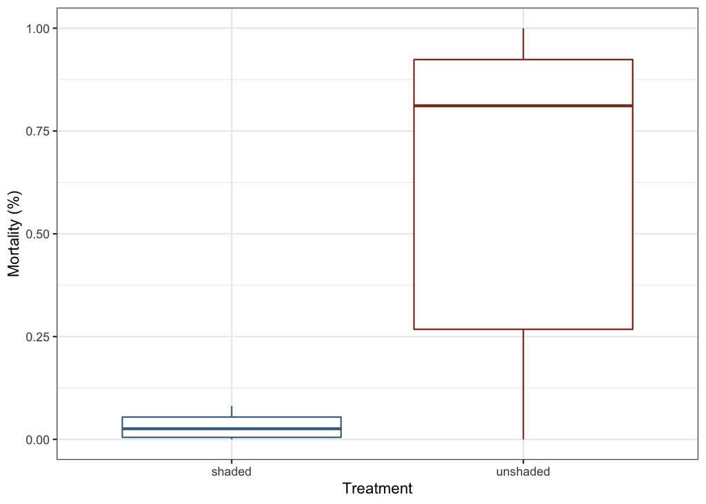

```r
ggplot(mort.beds %>% mutate(treatment = case_when(treatment == "SI" ~ "shaded", treatment == "UI" ~ "unshaded")), aes(x = treatment, y = prop_mort, col = treatment)) + geom_boxplot() + theme_bw() + scale_color_manual( values = c("skyblue4", "tomato4")) + labs(x = "Treatment", y = "Mortality (%)",col = "Treatment") + theme(legend.position = "none")
```

Clearly, having a shade positively affected barnacle survival. What about species richness/diversity based on visual surveys??

```r
visuals <- read_csv("../raw_data/shade/SBHW_SHADE_visual_3_202108.csv")

# separate the cover and count data

taxa <- read_csv("../raw_data/SBC_taxonomic_20211026.csv") %>% select(taxon_code, kingdom)

algae <- taxa %>% filter(kingdom != "Animalia") %>% select(-kingdom)
animal <- taxa %>% filter(kingdom == "Animalia") %>% select(-kingdom)

# algal diversity & abund

visuals.long <- visuals %>% pivot_longer(cols = c(2:length(visuals)), names_to = "taxon_code", values_to = "abund")

visuals.algae <- visuals.long %>% right_join(algae) %>% pivot_wider(names_from = "taxon_code", values_from = "abund") %>% select(-ULSP) %>% na.omit()

H <- diversity(visuals.algae)
total_cover <- rowSums(visuals.algae %>% select(-plot_number))

diversity.algae <- cbind(visuals.algae$plot_number, H, total_cover)
colnames(diversity.algae) <- c("plot_number","H", "total_cover")
diversity.algae <- as.data.frame(diversity.algae)

diversity.algae.trts <- diversity.algae %>% full_join(plot.info) %>% select(-plot_number, -treatment_final_numeric, -shore_level) %>% rename(treatment = treatment_original_numeric) %>% mutate(treatment = case_when(treatment == 1 ~ "UI", treatment == 2 ~ "SI", treatment == 3 ~ "UR", treatment == 4 ~ "SR"))

# animal diversity & abund

visuals.animals <- visuals.long %>% right_join(animal)  %>% pivot_wider(names_from = "taxon_code", values_from = "abund") %>% mutate_all(~replace_na(.,0)) %>% select(-c(GNOR:NEVE)) %>% na.omit()

H <- diversity(visuals.animals)
abund <- rowSums(visuals.animals %>% select(-plot_number))

diversity.animals <- cbind(visuals.animals$plot_number, H, abund)
colnames(diversity.animals) <- c("plot_number","H", "abund")
diversity.animals <- as.data.frame(diversity.animals)

diversity.animals.trts <- diversity.animals %>% full_join(plot.info) %>% select(-plot_number, -treatment_final_numeric, -shore_level) %>% rename(treatment = treatment_original_numeric) %>% mutate(treatment = case_when(treatment == 1 ~ "UI", treatment == 2 ~ "SI", treatment == 3 ~ "UR", treatment == 4 ~ "SR"))

richness.all.taxa <- cbind(visuals$plot_number, specnumber(visuals))
colnames(richness.all.taxa) <- c("plot_number", "richness")
richness.all.taxa <- as.data.frame(richness.all.taxa)

richness.all.trts <- richness.all.taxa %>% full_join(plot.info) %>% select(-plot_number, -treatment_final_numeric, -shore_level) %>% rename(treatment = treatment_original_numeric) %>% mutate(treatment = case_when(treatment == 1 ~ "UI", treatment == 2 ~ "SI", treatment == 3 ~ "UR", treatment == 4 ~ "SR"))
```

# Plots of diversity & abundance

## 1: Species richness, all taxa

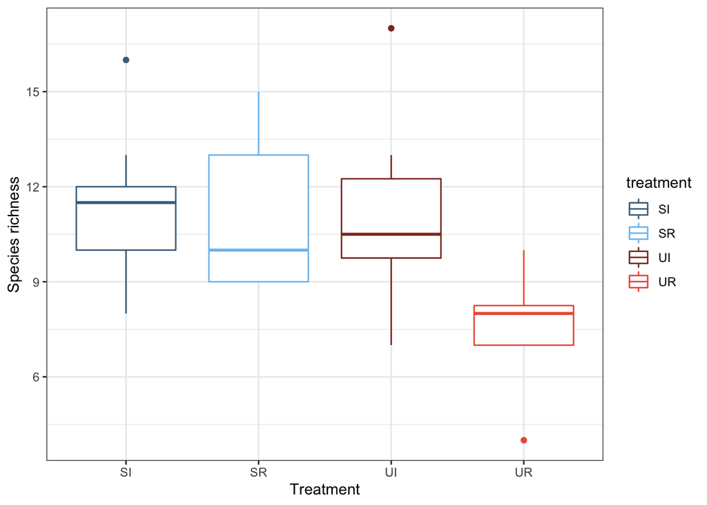

```r
ggplot(richness.all.trts, aes(x=treatment, y = richness, color = treatment)) + geom_boxplot() + labs(y = "Species richness", x = "Treatment") + scale_color_manual(values = c("skyblue4","skyblue2", "tomato4", "tomato2")) +  theme(axis.title = element_text(size = 14), axis.text = element_text(size = 12), legend.text = element_text(size = 12), legend.title = element_text(size = 14)) + theme_bw()
```

## 2: Animals only: Shannon diversity & total abundance

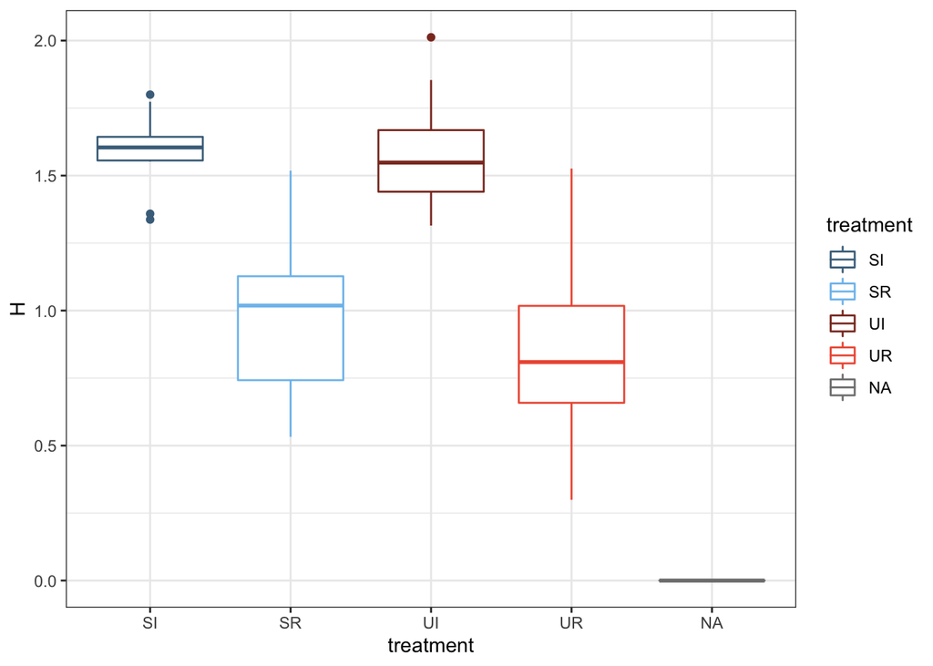

```r
ggplot(diversity.animals.trts, aes(x=treatment, y = H, color = treatment)) + geom_boxplot() + scale_color_manual(values = c("skyblue4","skyblue2", "tomato4", "tomato2")) +  theme(axis.title = element_text(size = 14), axis.text = element_text(size = 12), legend.text = element_text(size = 12), legend.title = element_text(size = 14)) + theme_bw()
```

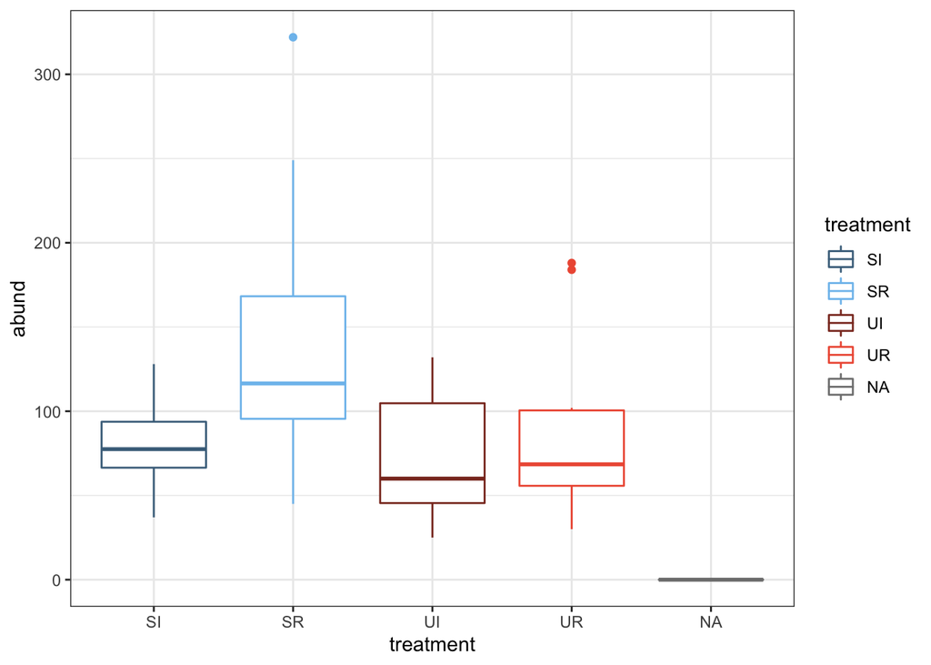

```r
ggplot(diversity.animals.trts, aes(x=treatment, y = abund, color = treatment)) + geom_boxplot() + scale_color_manual(values = c("skyblue4","skyblue2", "tomato4", "tomato2")) +  theme(axis.title = element_text(size = 14), axis.text = element_text(size = 12), legend.text = element_text(size = 12), legend.title = element_text(size = 14)) + theme_bw()
```

This trend is driven by barnacle recruitment, which was REALLY high in shaded removal plots. Might be worth digging into further??

```r
richness <- lm(richness ~ treatment, data = richness.all.trts)
summary(richness)
```

```
##
## Call:
## lm(formula = richness ~ treatment, data = richness.all.trts)
##
## Residuals:
##    Min     1Q Median     3Q    Max
## -4.000 -1.250 -0.125  1.083  6.000
##
## Coefficients:
##             Estimate Std. Error t value Pr(>|t|)
## (Intercept)  11.2500     0.6199  18.147  < 2e-16 ***
## treatmentSR  -0.2500     0.8767  -0.285 0.776862
## treatmentUI  -0.2500     0.8767  -0.285 0.776862
## treatmentUR  -3.5833     0.8767  -4.087 0.000182 ***
## ---
## Signif. codes:  0 '***' 0.001 '**' 0.01 '*' 0.05 '.' 0.1 ' ' 1
##
## Residual standard error: 2.147 on 44 degrees of freedom
## Multiple R-squared:  0.3422, Adjusted R-squared:  0.2974
## F-statistic:  7.63 on 3 and 44 DF,  p-value: 0.000326
```

```r
Anova(richness)
```

```
## Anova Table (Type II tests)
##
## Response: richness
##           Sum Sq Df F value   Pr(>F)
## treatment 105.56  3    7.63 0.000326 ***
## Residuals 202.92 44
## ---
## Signif. codes:  0 '***' 0.001 '**' 0.01 '*' 0.05 '.' 0.1 ' ' 1
```

```r
animal.diversity <- lm(H ~ treatment, data = diversity.animals.trts)
summary(animal.diversity)
```

```
##
## Call:
## lm(formula = H ~ treatment, data = diversity.animals.trts)
##
## Residuals:
##      Min       1Q   Median       3Q      Max
## -0.52955 -0.19417  0.00364  0.13055  0.69720
##
## Coefficients:
##             Estimate Std. Error t value Pr(>|t|)
## (Intercept)  1.59061    0.07688  20.689  < 2e-16 ***
## treatmentSR -0.60659    0.10873  -5.579 1.40e-06 ***
## treatmentUI -0.01461    0.10873  -0.134    0.894
## treatmentUR -0.76192    0.10873  -7.008 1.11e-08 ***
## ---
## Signif. codes:  0 '***' 0.001 '**' 0.01 '*' 0.05 '.' 0.1 ' ' 1
##
## Residual standard error: 0.2663 on 44 degrees of freedom
##   (1 observation deleted due to missingness)
## Multiple R-squared:  0.644,  Adjusted R-squared:  0.6197
## F-statistic: 26.53 on 3 and 44 DF,  p-value: 5.926e-10
```

```r
Anova(animal.diversity)
```

```
## Anova Table (Type II tests)
##
## Response: H
##           Sum Sq Df F value    Pr(>F)
## treatment 5.6452  3   26.53 5.926e-10 ***
## Residuals 3.1208 44
## ---
## Signif. codes:  0 '***' 0.001 '**' 0.01 '*' 0.05 '.' 0.1 ' ' 1
```

```r
animal.abundance <- lm(abund ~ treatment, data = diversity.animals.trts)
summary(animal.abundance)
```

```
##
## Call:
## lm(formula = abund ~ treatment, data = diversity.animals.trts)
##
## Residuals:
##    Min     1Q Median     3Q    Max
## -98.67 -30.50 -11.08  16.23 178.33
##
## Coefficients:
##             Estimate Std. Error t value Pr(>|t|)
## (Intercept)   79.833     15.202   5.251 4.19e-06 ***
## treatmentSR   63.833     21.499   2.969  0.00482 **
## treatmentUI   -8.750     21.499  -0.407  0.68599
## treatmentUR    7.917     21.499   0.368  0.71447
## ---
## Signif. codes:  0 '***' 0.001 '**' 0.01 '*' 0.05 '.' 0.1 ' ' 1
##
## Residual standard error: 52.66 on 44 degrees of freedom
##   (1 observation deleted due to missingness)
## Multiple R-squared:  0.2406, Adjusted R-squared:  0.1888
## F-statistic: 4.647 on 3 and 44 DF,  p-value: 0.006596
```

```r
Anova(animal.abundance)
```

```
## Anova Table (Type II tests)
##
## Response: abund
##           Sum Sq Df F value   Pr(>F)
## treatment  38660  3  4.6467 0.006596 **
## Residuals 122026 44
## ---
## Signif. codes:  0 '***' 0.001 '**' 0.01 '*' 0.05 '.' 0.1 ' ' 1
```

## 3: Algal diversity & cover

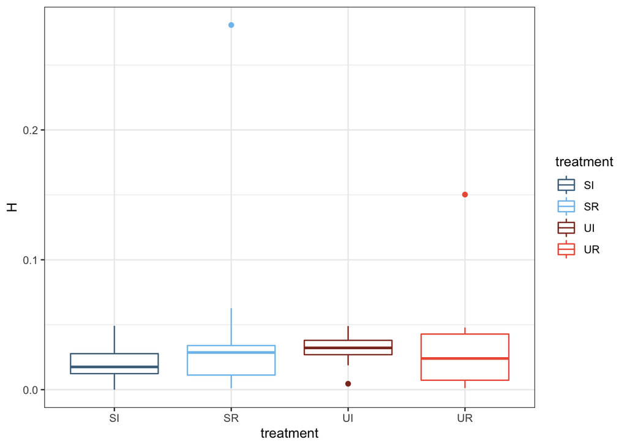

```r
ggplot(diversity.algae.trts, aes(x=treatment, y = H, color = treatment)) + geom_boxplot() + scale_color_manual(values = c("skyblue4","skyblue2", "tomato4", "tomato2")) +  theme(axis.title = element_text(size = 14), axis.text = element_text(size = 12), legend.text = element_text(size = 12), legend.title = element_text(size = 14)) + theme_bw()
```

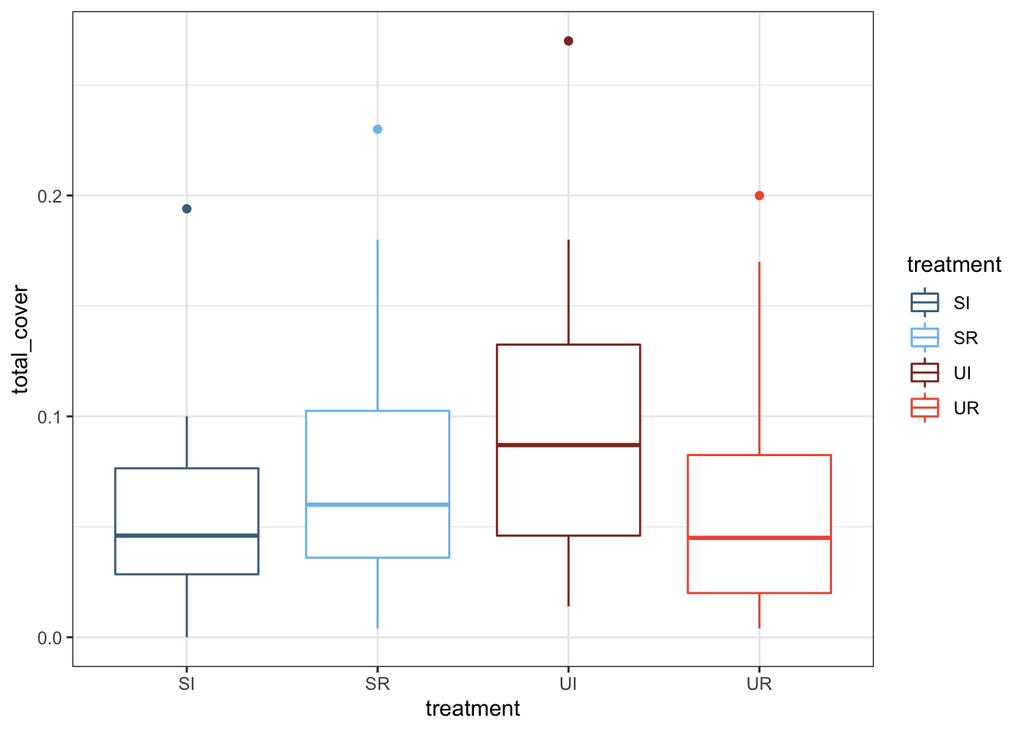

```r
ggplot(diversity.algae.trts, aes(x=treatment, y = total_cover, color = treatment)) + geom_boxplot() + scale_color_manual(values = c("skyblue4","skyblue2", "tomato4", "tomato2")) +  theme(axis.title = element_text(size = 14), axis.text = element_text(size = 12), legend.text = element_text(size = 12), legend.title = element_text(size = 14)) + theme_bw()
```

```r
algal.diversity <- lm(H ~ treatment, data = diversity.algae.trts)
summary(algal.diversity)
```

```
##
## Call:
## lm(formula = H ~ treatment, data = diversity.algae.trts)
##
## Residuals:
##       Min        1Q    Median        3Q       Max
## -0.044040 -0.018388 -0.006687  0.007550  0.235633
##
## Coefficients:
##             Estimate Std. Error t value Pr(>|t|)
## (Intercept)  0.02017    0.01274   1.583    0.121
## treatmentSR  0.02497    0.01802   1.386    0.173
## treatmentUI  0.01082    0.01802   0.601    0.551
## treatmentUR  0.01316    0.01802   0.730    0.469
##
## Residual standard error: 0.04413 on 44 degrees of freedom
## Multiple R-squared:  0.0422, Adjusted R-squared:  -0.02311
## F-statistic: 0.6462 on 3 and 44 DF,  p-value: 0.5895
```

```r
Anova(algal.diversity)
```

```
## Anova Table (Type II tests)
##
## Response: H
##             Sum Sq Df F value Pr(>F)
## treatment 0.003776  3  0.6462 0.5895
## Residuals 0.085700 44
```

```r
algal.cover <- lm(total_cover ~ treatment, data = diversity.algae.trts)
summary(algal.cover)
```

```
##
## Call:
## lm(formula = total_cover ~ treatment, data = diversity.algae.trts)
##
## Residuals:
##      Min       1Q   Median       3Q      Max
## -0.08733 -0.04063 -0.01717  0.02025  0.16867
##
## Coefficients:
##             Estimate Std. Error t value Pr(>|t|)
## (Intercept)  0.05900    0.01894   3.116  0.00323 **
## treatmentSR  0.02033    0.02678   0.759  0.45174
## treatmentUI  0.04233    0.02678   1.581  0.12109
## treatmentUR  0.00550    0.02678   0.205  0.83822
## ---
## Signif. codes:  0 '***' 0.001 '**' 0.01 '*' 0.05 '.' 0.1 ' ' 1
##
## Residual standard error: 0.0656 on 44 degrees of freedom
## Multiple R-squared:  0.06374,    Adjusted R-squared:  -9.546e-05
## F-statistic: 0.9985 on 3 and 44 DF,  p-value: 0.4025
```

```r
Anova(algal.cover)
```

```
## Anova Table (Type II tests)
##
## Response: total_cover
##            Sum Sq Df F value Pr(>F)
## treatment 0.01289  3  0.9985 0.4025
## Residuals 0.18933 44
```

Moral of the story: The animal component of the community seems way more affected than the algal component.

## Visual surveys NMDS

```r
comm.visual <- visuals %>% select(-plot_number)
comm.visual.matrix <- as.matrix(comm.visual)
View(visuals)
comm.visual <- metaMDS(comm.visual.matrix, k = 2, try = 999, autotransform = T)

treatment.codes <- as.data.frame(plot.info$treatment_original_numeric) %>% rename(treatment = 1)
```

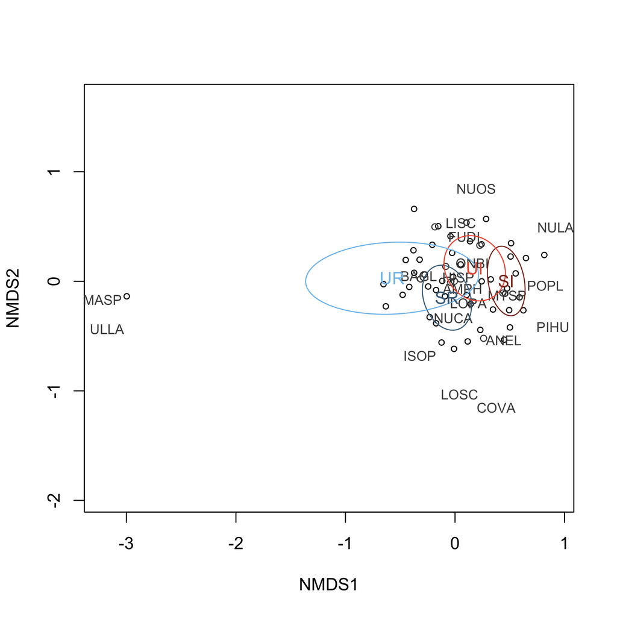

```r
knitr::include_graphics("../outputs/community_visual_shade.png")
```

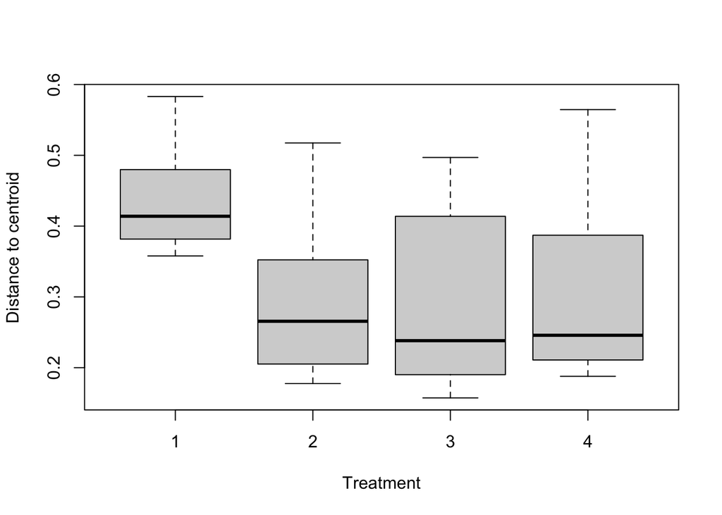

```r
perm.y1 <- adonis(comm.visual.matrix ~ treatment, data = treatment.codes, perm = 99)
perm.y1

dist.y1 <- vegdist(comm.visual.matrix, method = "bray")

disp.y1 <- betadisper(dist.y1, type = "centroid", group = treatment.codes$treatment)
anova(disp.y1)

boxplot(disp.y1, xlab = "Treatment")
```

[output not shown]

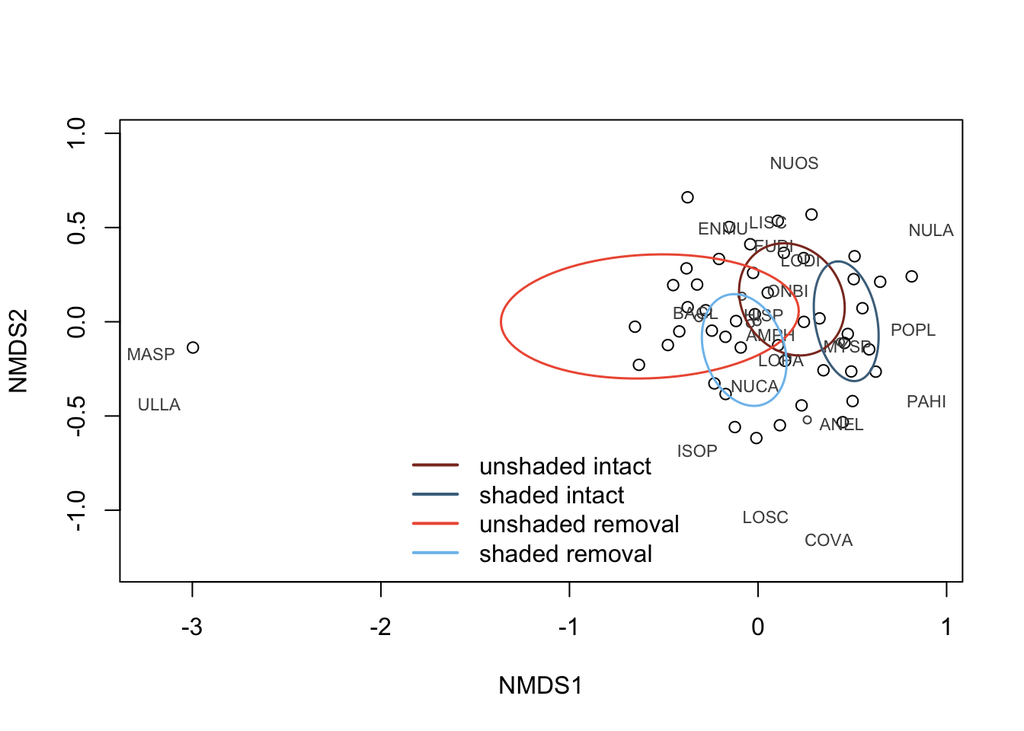

```r
comm_ord <- ordiplot(comm.visual, type = "none")
points(comm_ord, what = "sites", col = "black")
orditorp(comm_ord, display="species",col="grey30", air=1)
ordiellipse(comm_ord, groups = treatment.codes$treatment,
            col = c("tomato4","skyblue4", "tomato2","skyblue2"), lwd = 1.5)
legend("bottom", col = c("tomato4","skyblue4", "tomato2","skyblue2"), legend = c("unshaded intact","shaded intact", "unshaded removal","shaded removal"), bty = "n", lty = 1, lwd = 2)
```